# Question

A thief is stealing xots and yivs. Each xot has a mass of 7 kilograms and a volume of 9 liters. Each yiv has a mass of 14 kilograms and a volume of 12 liters. The thief can carry a maximum mass of 98 kilograms and a maximum volume of 108 liters. The profit from each xot is $6.88 and the profit from each yiv is $3.75.

For your convenience, those numbers are organized in the table below.

| attribute | xot | yiv | capacity |
| --- | --- | --- | --- |
| mass (kg) | 7 | 14 | 98 |
| volume (L) | 9 | 12 | 108 |
| profit ($) | 6.88 | 3.75 | $\infty$ |

What is the maximum profit the thief can produce? *(In dollars.)*

# Solution

This is an example of [linear programming](https://en.wikipedia.org/wiki/Linear_programming).

Define $x$ as number of xots and $y$ as number of yivs. Write the constraints as inequalities.

- Mass constraint: $7x+14y \le 98$
- Volume constraint: $9x+12y \le 108$

We can assume that optimal profit will occur at a boundary, so we can just consider the equations.
$$7x+14y =
98$$
$$9x+12y = 108$$

If either equation has coefficients that all share a common factor, we can simplify by dividing both sides by the greatest common factor:

$$1x+2y = 14$$
$$3x+4y = 36$$

We need to find the $x$ intercepts and the $y$ intercepts.

To find the $x$-intercepts, set $y$ to 0.

- The $x$-intercept of the mass constraint:
  $$1x_{\text{int}1}+(2)(0) = 14$$
  $$1x_{\text{int}1} = 14$$
  $$x_{\text{int}1} = \frac{14}{1} = 14$$
- The $x$-intercept of the volume constraint:

$$3x_{\text{int}2}+(4)(0) = 36$$
$$3x_{\text{int}2} = 36$$
$$x_{\text{int}2} = \frac{36}{3} = 12$$

To find the $y$-intercepts, set $x$ to 0.

- The $y$-intercept of the mass constraint:
  $$(1)(0)+(2)(y_{\text{int1}}) =
  14$$
  $$2y_{\text{int}1} = 14$$
  $$y_{\text{int}1} = \frac{14}{2} =
  7$$
- The $y$-intercept of the volume constraint:

$$(3)(0)+(4)y_{\text{int2}} = 36$$
$$4y_{\text{int}2} = 36$$
$$y_{\text{int}2} = \frac{36}{4} = 9$$

To find the intersection of the constraints, I would recommend elimination. Multiply the equations to have matching coefficients for $y$ terms.

$$2x + 4y = 28$$
$$3x + 4y = 36$$
Subtract equations.

$$1x + (0)y = 8$$

Simplify.

$$1x = 8$$

Divide by 1.

$$x = 8$$

Plug $x = 8$ into the first equation. Solve for $y$.

$$(1)(8)+2y = 14$$
$$8+2y = 14$$
$$2y = 6$$
$$y =
3$$

So, the intersection occurs at $(8,\,3)$.

You can plot the boundaries and shade the [feasible region](https://en.wikipedia.org/wiki/Feasible_region).

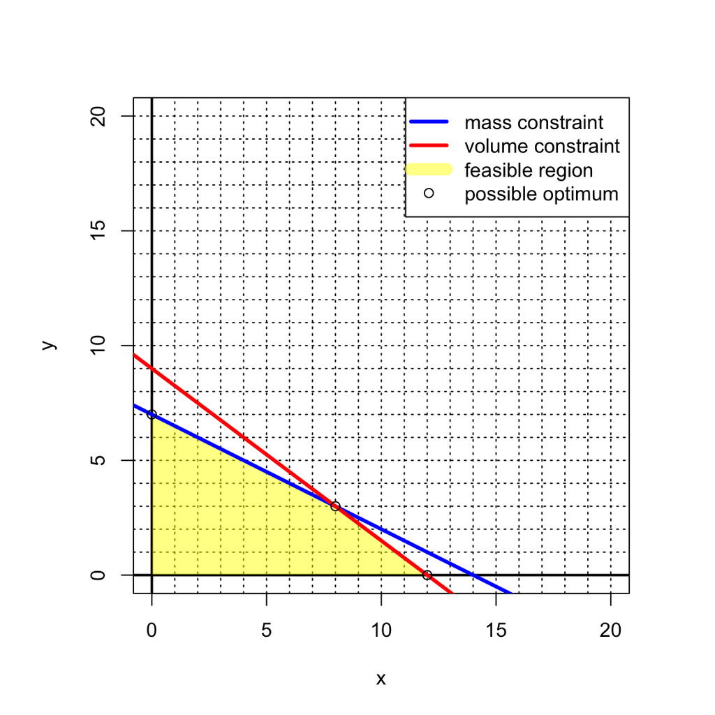

The maximum profit could occur at $(0,7)$ or $(8,3)$ or $(12,0)$.

Find those profits, using $P(x,y)=6.88x+3.75y$.

$$P(0,7)=(6.88)(0)+(3.75)(7) =
26.25$$
$$P(8,3)=(6.88)(8)+(3.75)(3) =
66.29$$
$$P(12,0)=(6.88)(12)+(3.75)(0)
= 82.56$$

So, the maximum profit is $82.56.

It might help to visualize this in 3D, with xots, yivs, and profit on the 3 axes. Sorry, I was not able to make a 3D plot show up here. But, we can add a third “dimension” by using a color ramp for profit. You can see that since our profit function is linear in $x$ and linear in $y$, the profit grows linearly as either xots or yivs are added. Another useful concept is an [isoprofit line](https://www.youtube.com/watch?v=QkIrNqiJZw4), which shows all the possible combinations of xots and yivs that would generate the same profit (see [contour lines](https://en.wikipedia.org/wiki/Contour_line)). Since profit is linear in both $x$ and $y$, we see the isoprofit lines are all parallel. Also, in this case, the isoprofit lines are not parallel to either constraint, so there will be only a single optimal choice.

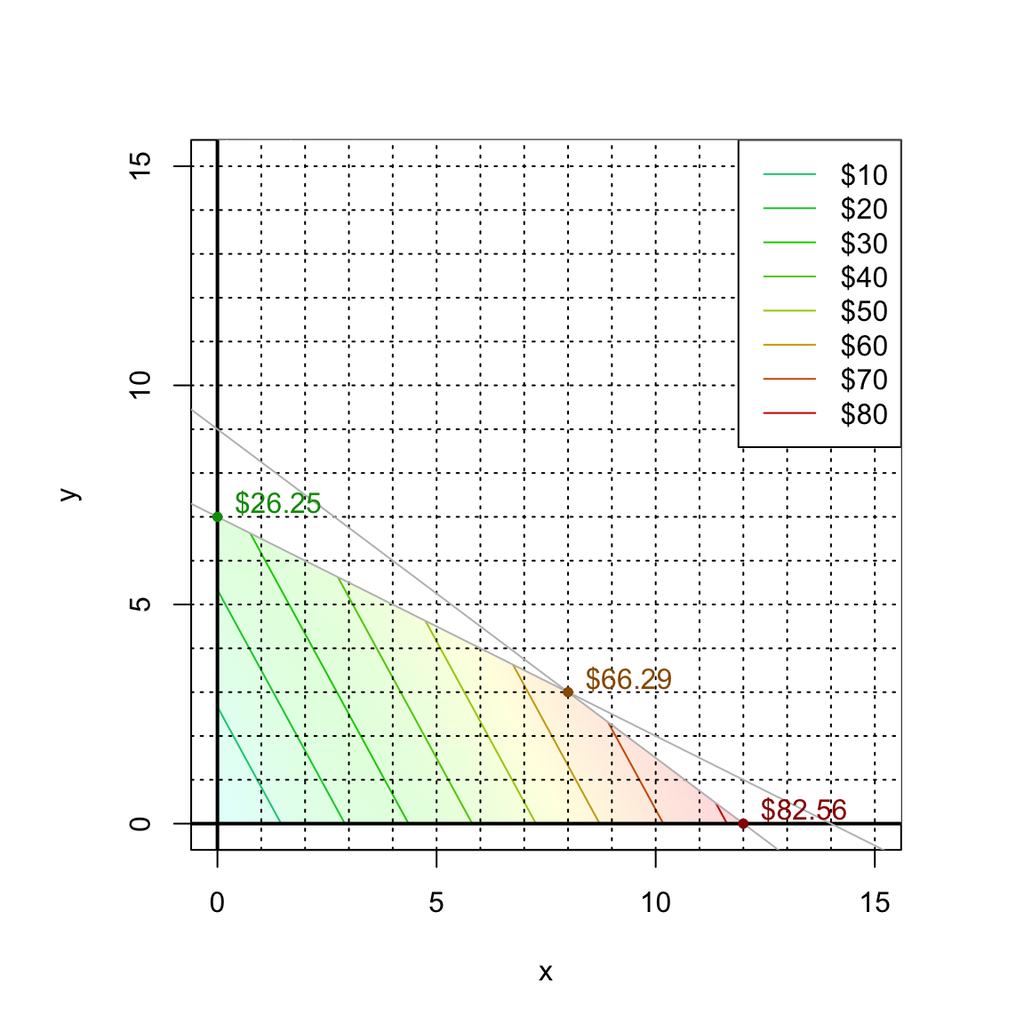

# Meta-information

extype: num exsolution: 82.56 extol: 0.01 exname: opt_thief